# Analytics Edge: Unit 3 - Evaluating Risk Factors to Save Lives

Sulman Khan

October 26, 2018

## The Framingham Heart Study

### Franklin Delano Roosevelt (FDR)

- President of the United States, 1933 - 1945
  - Longest-serving president
  - Led country through Great Depression
  - Commander in Chief of US military in World War II
- Died while president, April 12, 1945

### FDR’s Blood Pressure

- Before presidency, blood pressure of 140/100
  - Healthy blood pressure is less than 120/80
  - Today, this is already considered high blood pressure
- One year before death, 210/120
  - Today, this is called Hypertensive Crisis, and emergency care is needed
  - FDR’s personal physician: “A moderate degree of arteriosclerosis, although no more than normal for a man of his age”
- Two months before death: 260/150
- Day of death: 300/190

### Early Misconceptions

- High blood pressure dubbed *essential hypertension*
  - Considered important to force blood through arteries
  - Considered harmful to lower blood pressure
- Today, presidential blood pressure numbers like FDR’s would send the country’s leading doctors racing down hallways … whisking the nation’s leader into cardiac care unit of Bethesda Naval Hospital." " - Daniel Levy, Framingham Heart Study Director

### How Did We Learn?

- In late 1940s, U.S. Government set out to better understand cardiovascular disease (CVD)
- Plan: track large cohort of initially health patients over time
- City of Framingham, MA selected as site for study
  - Appropriate size
  - Stable population
  - Cooperative doctors and residents
- 1948: beginning of Framingham Heart Study

### The Framingham Heart Study

- 5,209 patients aged 30-59 enrolled
- Patients given questionnaire and exams every 2 years
  - Physical characteristics
  - Behavioral characteristics
  - Test results
- Exams and questions expanded over time
- We will build models using the Framingham data to predict and prevent heart disease

### Analytics to Prevent Heart Disease

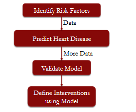

### Coronary Heart Disease (CHD)

- We will predict 10-year risk of CHD
  - Subject of important 1998 paper, introducing the Framingham Risk Score
- CHD is a disease of the blood vessels supplying the heart
- Heart disease has been leading the cause of death worldwide since 1921
  - 7.3 million people died from CHD in 2008
  - Since 1950, age-adjusted death rates have declined 60%

### Risk Factors

- *Risk factors* are variables that increase the chances of a disease
- Term coined by William Kannel and Roy Dawber from the Framing Ham Heart Study
- Key to successful prediction of CHD: identifying important risk factors

### Hypothesized CHD Risk Factors

- We will investigate risk factors collected in the first data collection for the study
  - Anonymized version of original data
- Demographic risk factors
  - *male*: sex of patient
  - *age*: age in years at first examination
  - *education*: Some high school (1), high school/GED (2), some college/vocation school (3), college(4)

### An Analytical Approach

- Randomly split patients into training and testing sets
- Use logistic regression on training set to predict whether or not a patient experienced CHD within 10 years of first examination
- Evaluate predictive power on test set

### Model Strength

- Model rarely predicts 10-year CHD risk above 50%
  - Accuracy very near a baseline of always predicting no CHD
- Model can differentiate low-risk from high-risk patients (AUC = 0.74)
- Some significant variable suggest interventions
  - Smoking
  - Cholesterol
  - Systolic blood pressure
  - Glucose

### Risk Model Validation

- So far, we have used *internal validation*
  - Train with some patients, test with others
- Weakness: unclear if model generalizes to other populations
- Framingham color white, middle class
- Important to test on other populations

### Framingham Risk Model Validation

- Framingham Risk Model tested on diverse cohorts

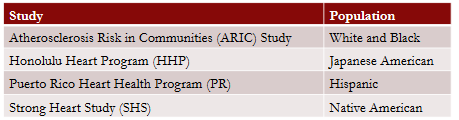

- Cohort studies collecting same risk factors
- Validation Plan
  - Predict CHD risk for each patient using FHS model
  - Compare to actual outcomes for each docile

### Drugs to Lower Blood Pressure

- In FDR’s time, hypertension drugs too toxic for practical use
- In 1950s, the diuretic chlorothiazied was developed
- Framingham Heart Study gave Ed Freis the evidence needed to argue for testing effects of BP drugs
- Veterans Administration (VA) Trial: randomized, double blind clinical trial
- Found decreased risk of CHD
- Now, >$1B market for diuretics worldwide

### Drugs to Lower Cholesterol

- Despite Framingham results, early cholesterol drugs too toxic for practical use
- In 1970s, first statins were developed
- Study of 4,444 patients with CHD: status cause 37% risk reduction of second heart attack
- Study of 6,595 men with high cholesterol: statins cause 32% risk reduction of CVD deaths
- Now, > $20B market for statins worldwide

### Research Directions and Challenges

- Second generation enrolled in 1971, third in 2002
  - Enables study of family history as a risk factor
- More diverse cohorts begun in 1994 and 2003
- Social network analysis of participants
- Genome-wide association study linking studying genetics as risk factors
- Many challenges related to funding
  - Funding cuts in 1969 nearly closed study
  - 2013 sequester threatening to close study

### Clinical Decision Rules

- Paved the way for *clinical decision rules*
- Predict clinical outcomes with data
  - Patient and disease characteristics
  - Test results
- More than 75,000 published across medicine
- Rate increasing

## Framingham Heart Study in R

### Load in the dataset

```r
# Read in the dataset
framingham = read.csv("framingham.csv")
```

### Examine structure

```r
# Look at structure
str(framingham)
```

```
## 'data.frame':    4240 obs. of  16 variables:
##  $ male           : int  1 0 1 0 0 0 0 0 1 1 ...
##  $ age            : int  39 46 48 61 46 43 63 45 52 43 ...
##  $ education      : int  4 2 1 3 3 2 1 2 1 1 ...
##  $ currentSmoker  : int  0 0 1 1 1 0 0 1 0 1 ...
##  $ cigsPerDay     : int  0 0 20 30 23 0 0 20 0 30 ...
##  $ BPMeds         : int  0 0 0 0 0 0 0 0 0 0 ...
##  $ prevalentStroke: int  0 0 0 0 0 0 0 0 0 0 ...
##  $ prevalentHyp   : int  0 0 0 1 0 1 0 0 1 1 ...
##  $ diabetes       : int  0 0 0 0 0 0 0 0 0 0 ...
##  $ totChol        : int  195 250 245 225 285 228 205 313 260 225 ...
##  $ sysBP          : num  106 121 128 150 130 ...
##  $ diaBP          : num  70 81 80 95 84 110 71 71 89 107 ...
##  $ BMI            : num  27 28.7 25.3 28.6 23.1 ...
##  $ heartRate      : int  80 95 75 65 85 77 60 79 76 93 ...
##  $ glucose        : int  77 76 70 103 85 99 85 78 79 88 ...
##  $ TenYearCHD     : int  0 0 0 1 0 0 1 0 0 0 ...
```

### Split the dataset

```r
# Load the library caTools
library(caTools)

# Randomly split the data into training and testing sets
set.seed(1000)
split = sample.split(framingham$TenYearCHD, SplitRatio = 0.65)

# Split up the data using subset
train = subset(framingham, split==TRUE)
test = subset(framingham, split==FALSE)
```

### Logistic Regression

```r
# Logistic Regression Model
framinghamLog = glm(TenYearCHD ~ ., data = train, family=binomial)
summary(framinghamLog)
```

```
##
## Call:
## glm(formula = TenYearCHD ~ ., family = binomial, data = train)
##
## Deviance Residuals:
##     Min       1Q   Median       3Q      Max
## -1.8487  -0.6007  -0.4257  -0.2842   2.8369
##
## Coefficients:
##                  Estimate Std. Error z value Pr(>|z|)
## (Intercept)     -7.886574   0.890729  -8.854  < 2e-16 ***
## male             0.528457   0.135443   3.902 9.55e-05 ***
## age              0.062055   0.008343   7.438 1.02e-13 ***
## education       -0.058923   0.062430  -0.944  0.34525
## currentSmoker    0.093240   0.194008   0.481  0.63080
## cigsPerDay       0.015008   0.007826   1.918  0.05514 .
## BPMeds           0.311221   0.287408   1.083  0.27887
## prevalentStroke  1.165794   0.571215   2.041  0.04126 *
## prevalentHyp     0.315818   0.171765   1.839  0.06596 .
## diabetes        -0.421494   0.407990  -1.033  0.30156
## totChol          0.003835   0.001377   2.786  0.00533 **
## sysBP            0.011344   0.004566   2.485  0.01297 *
## diaBP           -0.004740   0.008001  -0.592  0.55353
## BMI              0.010723   0.016157   0.664  0.50689
## heartRate       -0.008099   0.005313  -1.524  0.12739
## glucose          0.008935   0.002836   3.150  0.00163 **
## ---
## Signif. codes:  0 '***' 0.001 '**' 0.01 '*' 0.05 '.' 0.1 ' ' 1
##
## (Dispersion parameter for binomial family taken to be 1)
##
##     Null deviance: 2020.7  on 2384  degrees of freedom
## Residual deviance: 1792.3  on 2369  degrees of freedom
##   (371 observations deleted due to missingness)
## AIC: 1824.3
##
## Number of Fisher Scoring iterations: 5
```

### Make Predictions

```r
# Predictions on the test set
predictTest = predict(framinghamLog, type="response", newdata=test)

# Confusion matrix with threshold of 0.5
z = table(test$TenYearCHD, predictTest > 0.5)
kable(z)
```

|  | FALSE | TRUE |
| --- | --- | --- |
| 0 | 1069 | 6 |
| 1 | 187 | 11 |

```r
# Accuracy
(1069+11)/(1069+6+187+11)
```

```
## [1] 0.8483896
```

```r
# Baseline accuracy
(1069+6)/(1069+6+187+11)
```

```
## [1] 0.8444619
```

### AUC

```r
# Test set AUC
library(ROCR)
ROCRpred = prediction(predictTest, test$TenYearCHD)
as.numeric(performance(ROCRpred, "auc")@y.values)
```

```
## [1] 0.7421095
```